# Weekly Energy Charts

October 28, 2022

Sign up to receive our email updates via [Substack](https://leach.substack.com/)

[interactive chart not shown]

# Featured Stories

## Tariffs vs. Climate Action

#### [Marc Vermette](https://www.linkedin.com/in/marc-vermette/)

[A new study](https://www.nature.com/articles/s41586-022-05316-6) looks at how policies and tariffs created to protect manufacturers of renewable technologies, especially solar energy, threaten efforts to combat climate change globally.

Prices for solar modules could be as much as 25% higher than they would otherwise be by 2030 because of tariffs and other protectionist or nationalist policies.

[figure not shown]

Credit to Pixabay

[John Helveston](https://www.jhelvy.com/), the author of the study, stressed the role of cost minimization in making renewable energy technology “more attractive” to prospective consumers.” He also pointed out that low-carbon technologies could be an area for the US and China to collaborate, given that they are not as politically sensitive as other industries. China is responsible for the manufacturing of 79% of the world’s panels, according to Bloomberg New Energy Finance data. The study warned against relying on a single or a few countries only for supply chains. “We need to have local manufacturers for resilience purposes,” Helveston said, “but [not] at the expense of also trading with China. We should be doing both.”

Trade disputes are not new to the renewable power sector. The solar industry has been [involved in trade conflicts](https://www.brookings.edu/blog/planetpolicy/2018/02/09/what-past-experience-tells-us-about-the-impact-of-new-american-solar-tariffs/) for over a decade.

[Original Article](https://www.bloomberg.com/news/articles/2022-10-26/tariffs-threaten-to-undermine-global-shift-to-clean-energy)

## Renewable Investments Needed

#### [Marc Vermette](https://www.linkedin.com/in/marc-vermette/)

It’s IEA World Energy Outlook Week, so plenty of charts from them are coming your way in the next while!

The IEA says that renewables spending needs to more than triple globally in order to be on track to meet the goals set out in the Paris climate accord. This means that annual investments into renewable energy will need to reach $1.3 trillion per year by 2030.

This amount is over triple the $390 billion spent annually on renewables currently. However, the $1.3 trillion goal is not unprecedented for the energy industry. This amount would be equal to a previous record, set in 2014, for investment into fossil fuels.

In order to keep global warming to less than 2 degrees Celsius, wealthy countries will need to eliminate emissions entirely from their power sectors by 2035. Developing economies would need to follow suit by 2040, said the IEA in its World Energy Outlook.

Currently, decarbonizing the electricity sector is one of the cheapest and easiest ways to cut emissions. Solar and wind technology [prices have risen recently](https://www.energyintel.com/00000184-0971-d1bb-a39f-3df73fee0000) due to higher commodity prices and issues within their supply chains. However, they are becoming increasingly competitive, especially compared to other, more expensive, fossil-fuel alternatives.

[Original Article](https://www.bloomberg.com/news/articles/2022-10-27/renewables-need-1-3-trillion-per-year-by-2030-for-climate-goals?leadSource=uverify%20wall)

## World’s Largest Renewable Power Plant

#### [Yousaff Habib](https://www.linkedin.com/in/yousaff-habib-6684891a5/)

Over the past decade, China has shown a strong commitment to renewable energy, with 1063 GW of installed renewable generation capacity (nearly 45% of the nation’s total generation capacity). It comes as little surprise that the world’s largest renewable plant, an offshore wind farm, will be constructed in southern China.

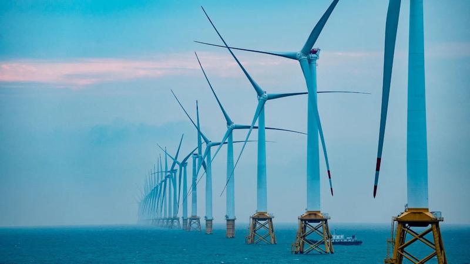

Offshore Wind Farms

The 43 GW wind farm will be built in the Taiwan Strait, off the coast of the city of Chaozhou, located in the province of Guangdong. This was an ideal location for the wind farm – unique topographical features create high wind speeds, which allow for the turbines to run 43-49% of the time. This is an unusually high capacity factor, and is a definite boon for the project. China currently has the largest fleet of offshore wind farms in the world, and with this addition, it’s unlikely that title will be taken from them any time soon.

For further reading, check out [this link](https://www.bloomberg.com/news/articles/2022-10-21/chinese-city-plans-offshore-wind-farm-that-could-power-norway) or if you’re really interested, the documents regarding the plans are available on [this website](https://news.bjx.com.cn/html/20221021/1262707-3.shtml). You might have to use translate for the latter however!

## Transparent Solar Panels

#### Debosree Mukherjee

A team of scientists at École Polytechnique Fédérale de Lausanne have been able to increase the efficiency for dye-sensitized solar cells (DSC). The new efficiency levels mean that [DSCs could potentially be used to produce transparent solar panels](https://www.independent.co.uk/tech/solar-panel-world-record-window-b2211057.html) at a larger scale. Specially designed photosensitizer dye molecules that can harvest light from the entire visible light spectrum were used to achieve the breakthrough. This advancement makes DSCs excellent candidates for making electricity-generating windows, greenhouses, and even screens of low-powered electronic devices. They are comparatively low-cost and can be produced using conventional techniques, making the commercial use of the material a viable option.

The full study can be found [here](https://www.nature.com/articles/s41586-022-05460-z).

# Oil

## Weekly Crude Prices

### Feature Crude

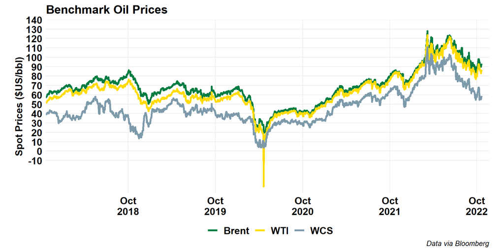

### Alberta Crude

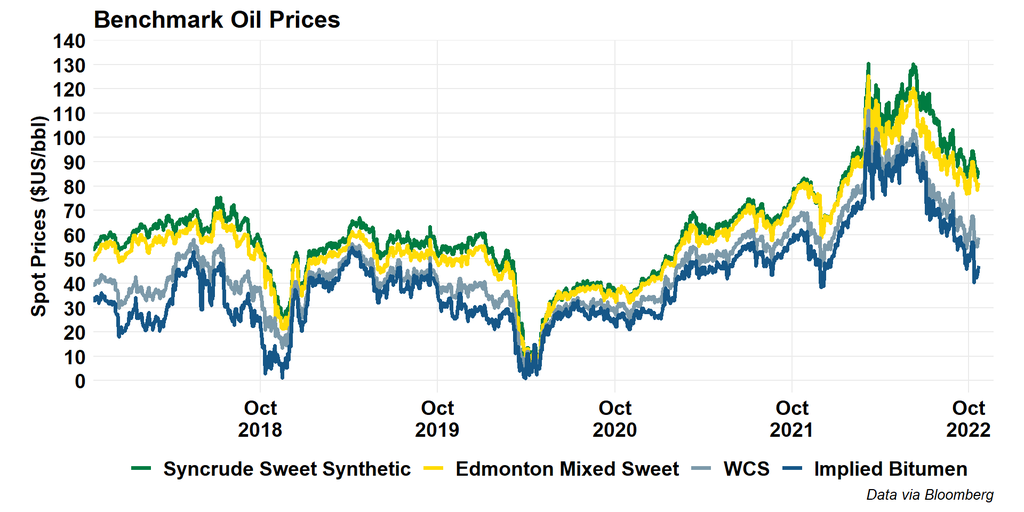

### Alberta Crude (Short)

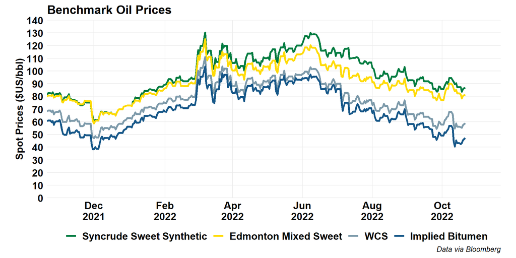

### US Crude

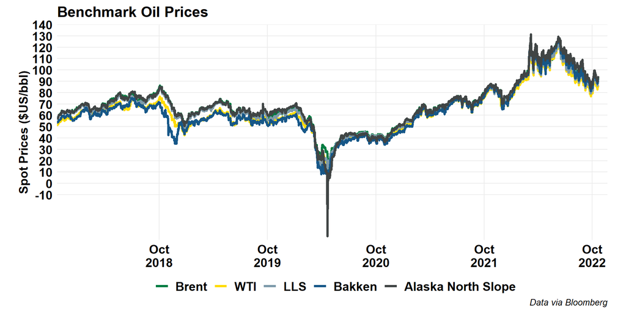

### Global Crude

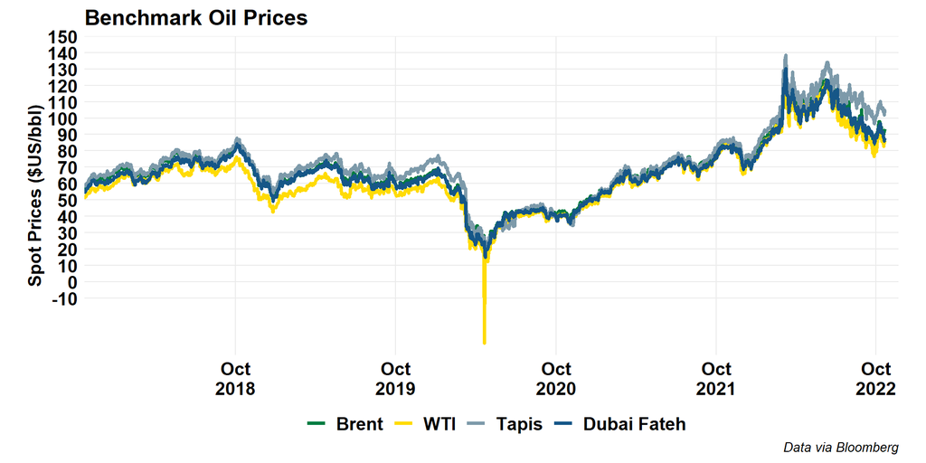

## Oil Price Differentials

### Brent-WTI

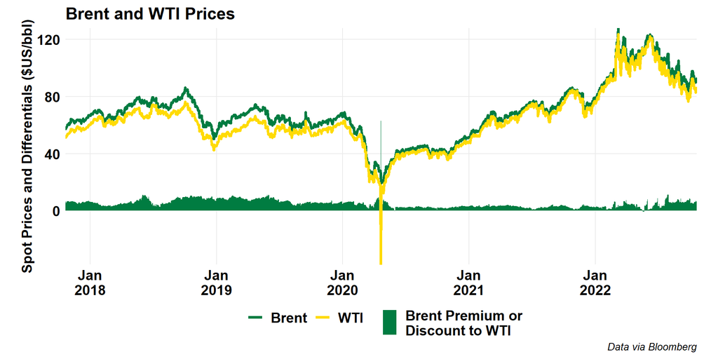

### WTI-WCS

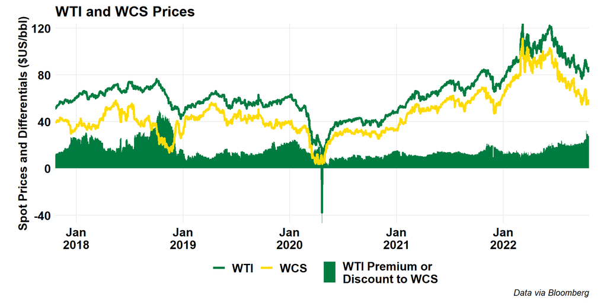

### WTI-WCS (Short)

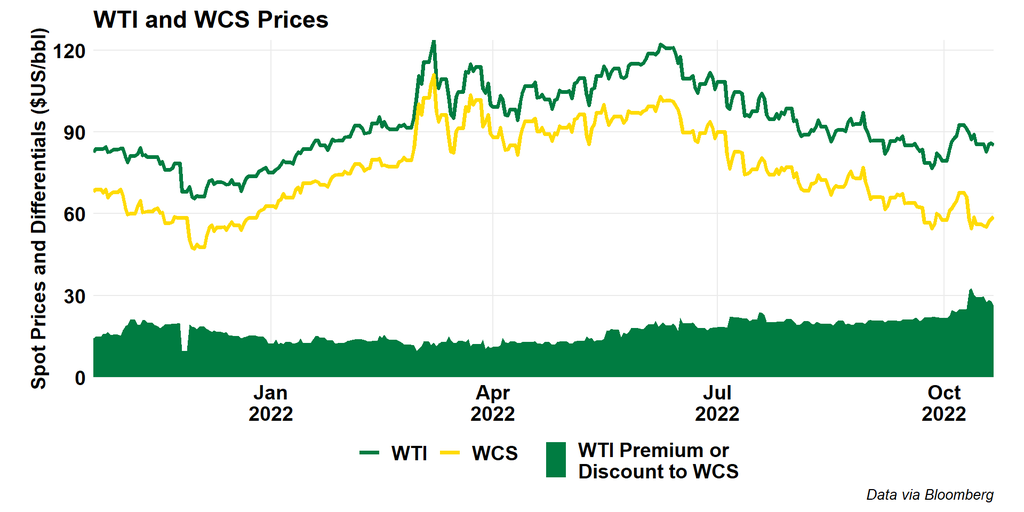

### Maya-WCS

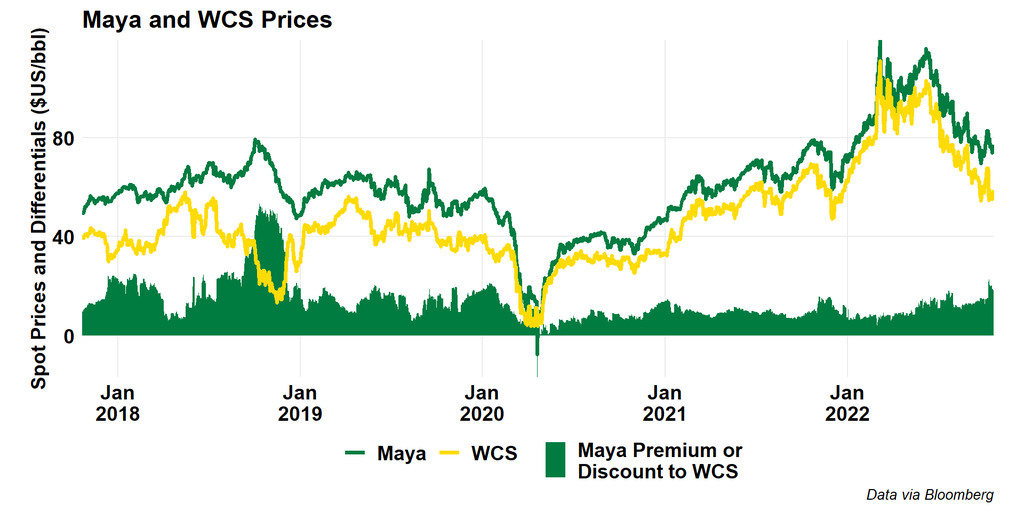

### WTI Cushing vs MEH

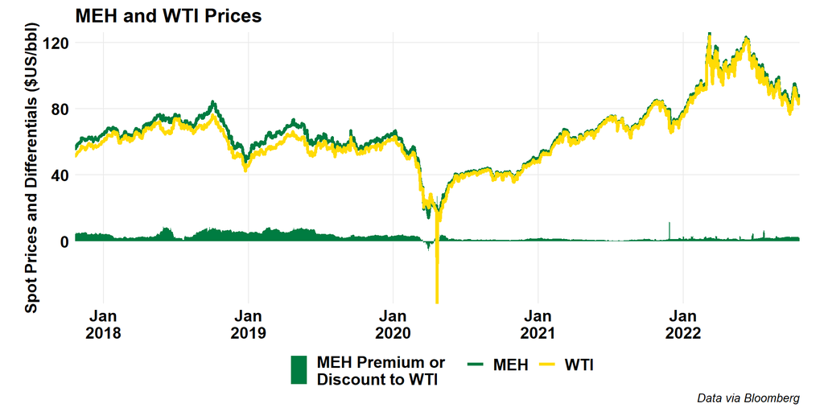

## Forward Curves

### WTI

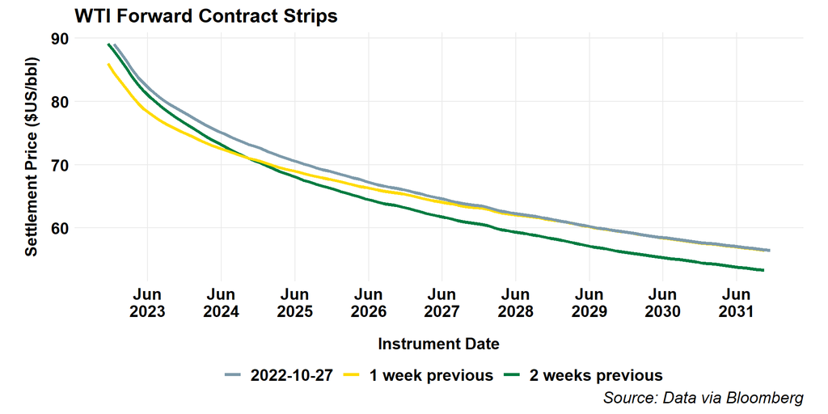

### Brent

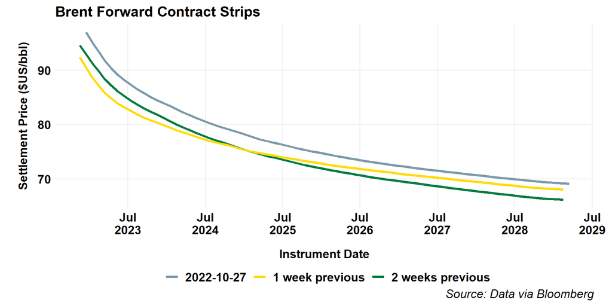

## Canadian Crude Supply and Disposition

### Production

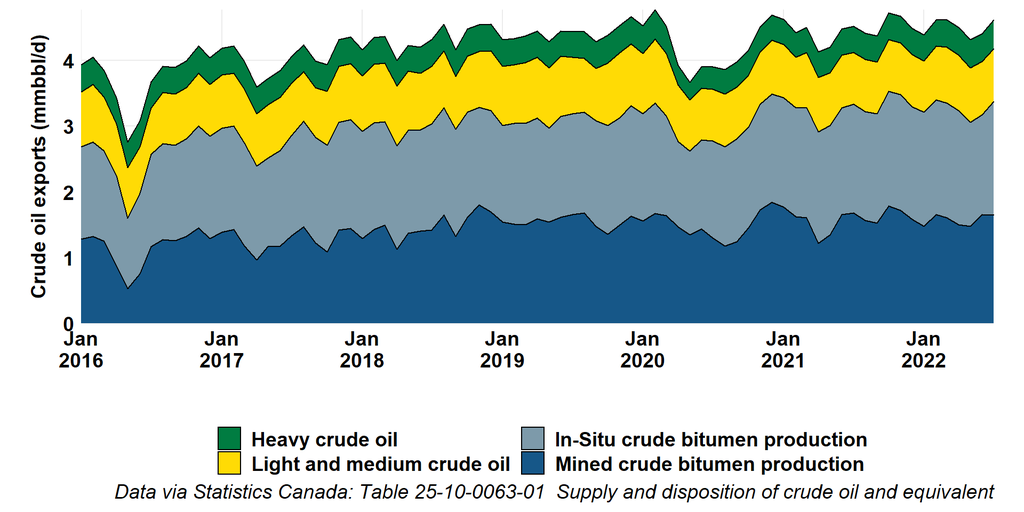

### Alberta Production

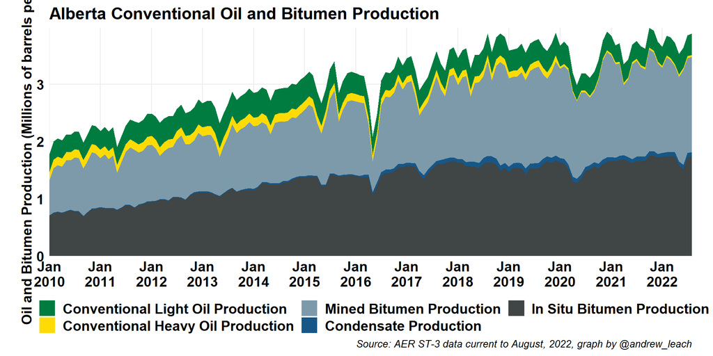

### Imports

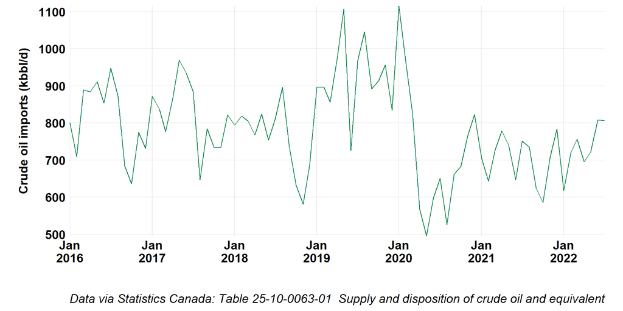

### Exports

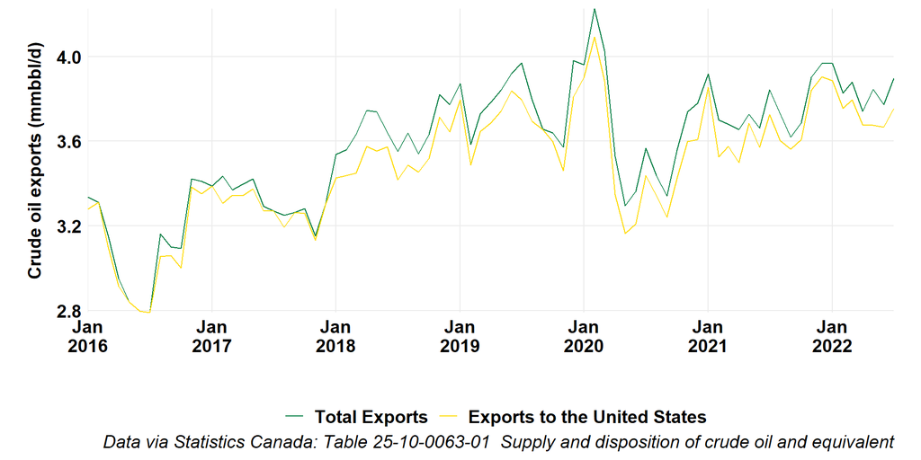

### Rail Exports

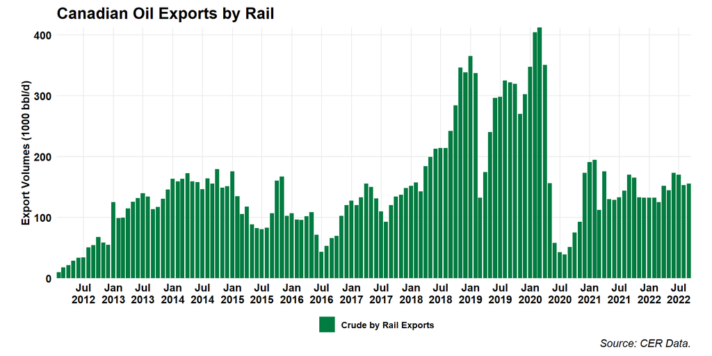

## US Oil

### Production

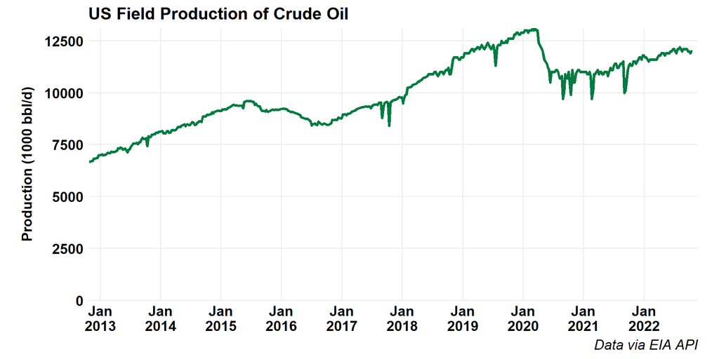

### LTO Production by Play

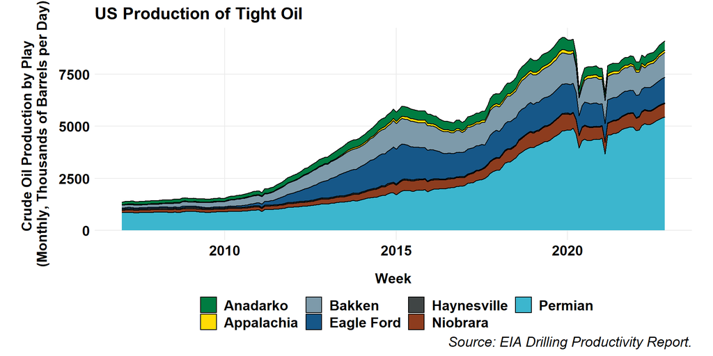

### Net Imports

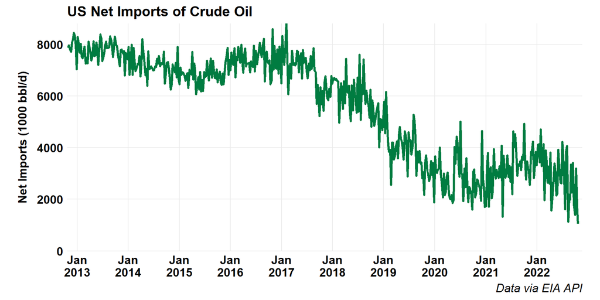

### Oil and Product Net Imports

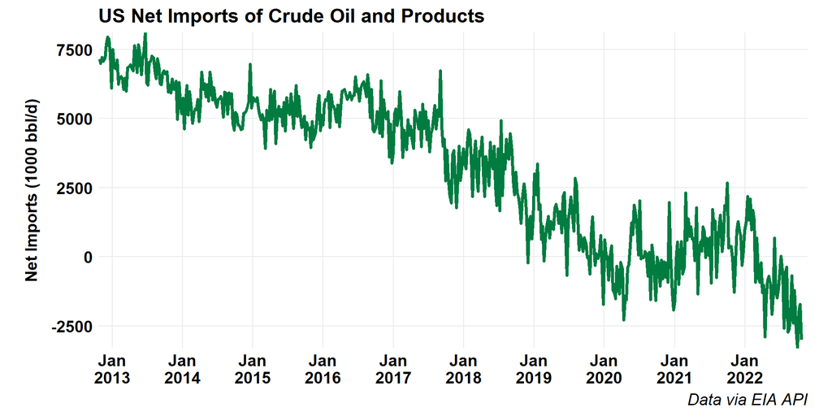

### Inventories

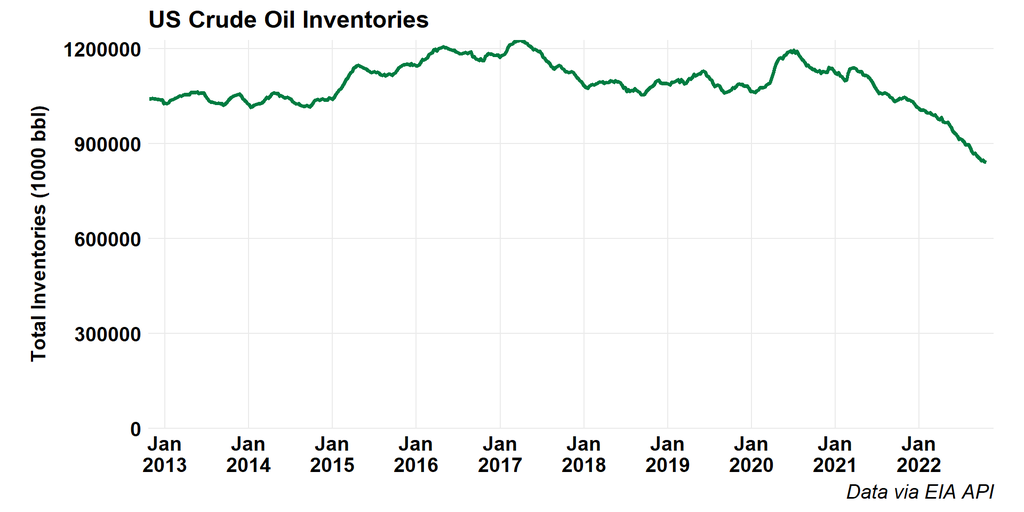

### EIA STEO Forecasts

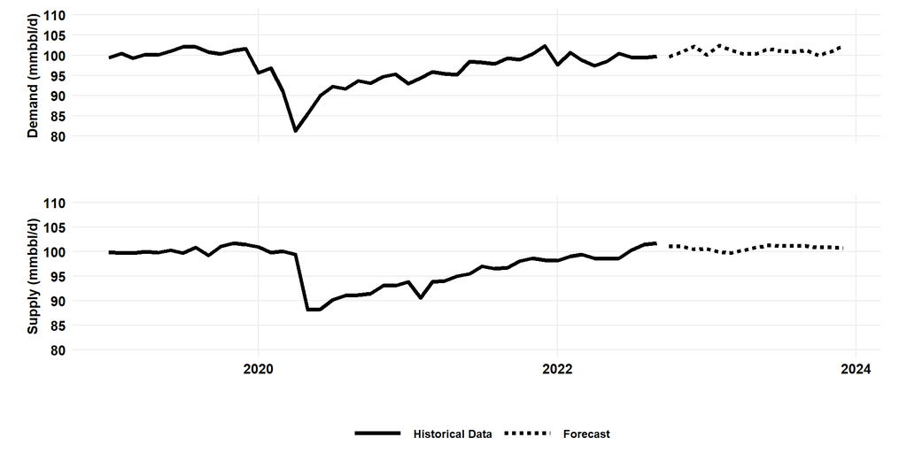

# Refined Products

## Canadian Gasoline Prices

### Map

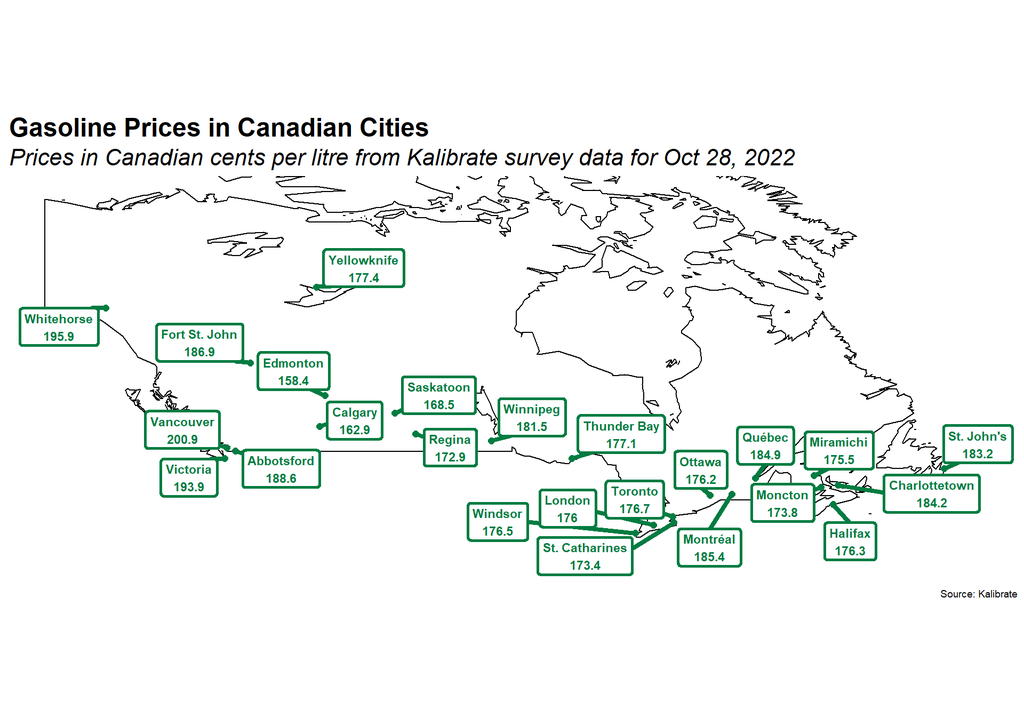

### Historic Gasoline Prices

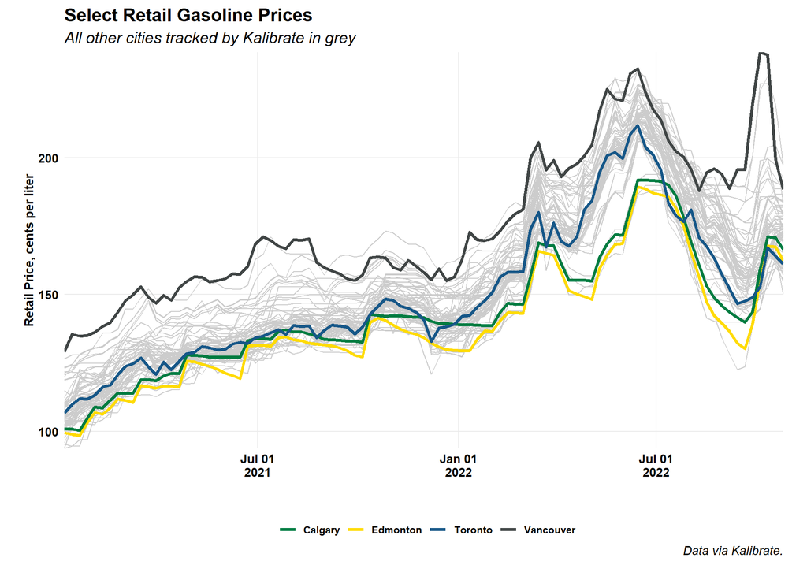

### Historic Gasoline Prices in BTC

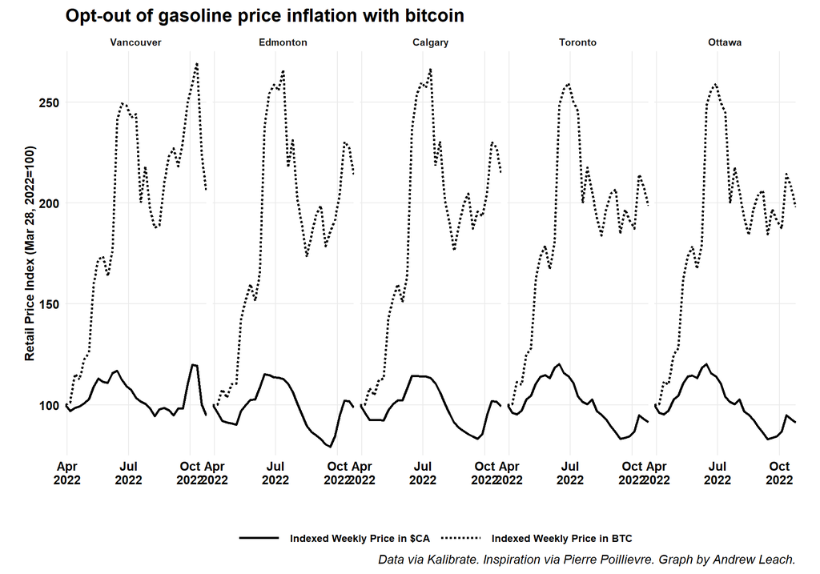

### Historic Diesel Prices

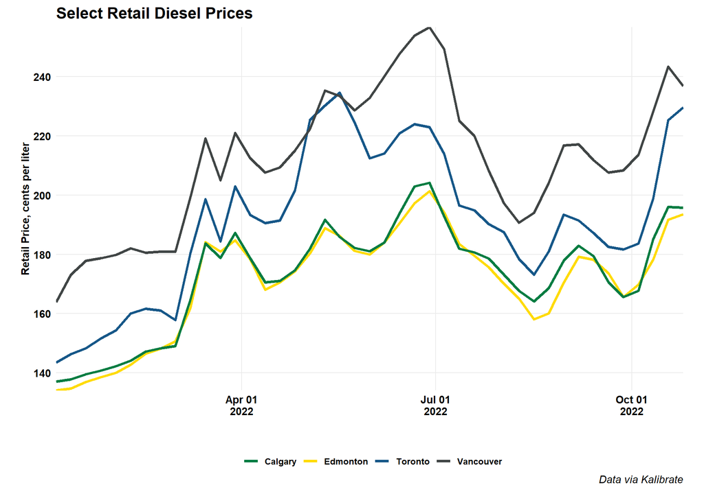

## Canadian Refinery Runs

### Canadian Refinery Runs

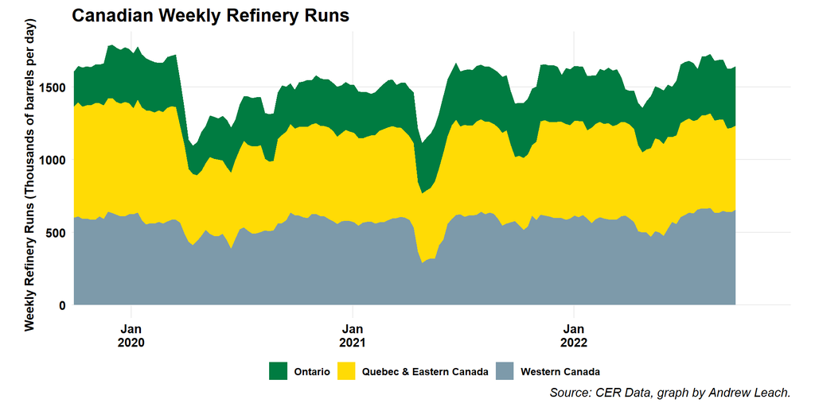

### Western Canada Refinery Runs

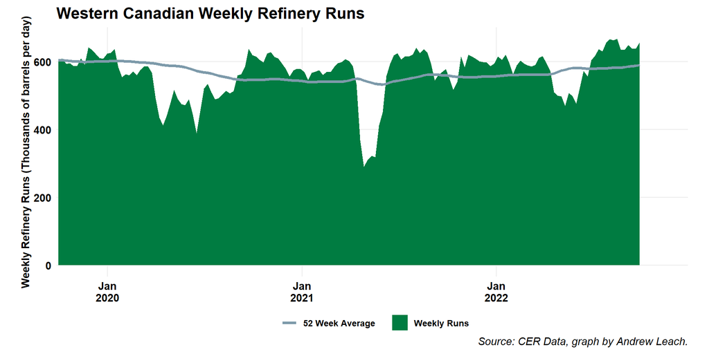